# Report for Tissue-Specific Proteins

Angela Yoder

2022-02-09

**The goals of this program are:**

1. Report results of tissue-specific proteins data
1. Flow chart of data reduction
2. Create tissue exclusive datasets (sec/nonsec)
3. Data summary
4. Compare heritability between tissue-exclusive secreted and tissue-exclusive non-secreted

The ensembl rat liver and brain RNAseq data was produced by our lab from tissues imported from the Czech Academy of Sciences laboratory. Inbred strains were excluded, leaving only recombinant inbred strains. The means across strains were calculated for the RNA expression data. Annontation data was retrieved from BiomaRt (version number 2.48.0), which was used to exclude non-protein-coding genes from the data set. This resulted in a dataset of 30 strains and 16,457 genes for brain tissue, and 30 strains and 14,109 genes for liver tissue.

From there, our datasets were segregated by terms “secreted” and “tissue-specific.” Results for protein-coding genes were filtered by species “Rattus norvegicus” and subcellular location “secreted” from the uniprot database (accessed 2021). The uniprot IDs from the new secreted dataset were compared to the converted uniprot IDs (via biomaRt) of the brain and liver tissue datasets. Tissue-specific status was determined by finding the genes in the brain and liver datasets were exclusive to those datasets (only found in the brain dataset OR the liver dataset). From this we created our dataset of investigation: tissue-specific secreted gene datasets for liver (with 35 genes) and brain (with 174 genes) tissues. This dataset was compared to a comparable dataset of tissue-specific non-secreted genes, with 368 liver genes and 2,577 brain genes.

The following report was completed using R version 4.1.1 (2021-08-10). Additionally, the packages WGCNA (version 1.70.3), broom (version 0.7.7), tidyverse (version 1.3.1), and knitr (version 1.33).

[interactive chart not shown]

|  | Number of Ensembl Genes |
| --- | --- |
| Brain: Full Data | 16457 |
| Brain: Tissue-Specific Non-Secreted Data | 2577 |
| Brain: Tissue-Specific Secreted Data | 174 |
| Liver: Full Data | 14109 |
| Liver: Tissue-Specific Non-Secreted Data | 368 |
| Liver: Tissue-Specific Secreted Data | 35 |
| Total Tissue-Specific Non-Secreted Rat Genes | 2945 |
| Total Tissue-Specific Secreted Rat Genes | 209 |

The R-squared density curves for the brain data below show similar peaks. The curves for the liver data indicate a greater right skew in the tissue-specific proteins. For both sets of data, the distinction is not as clear as the secreted proteins dataset, likely due to small sample size.

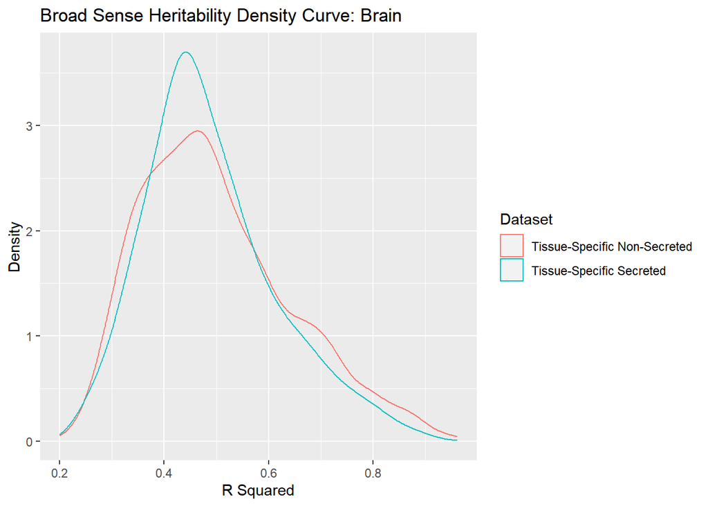

[figure not shown]

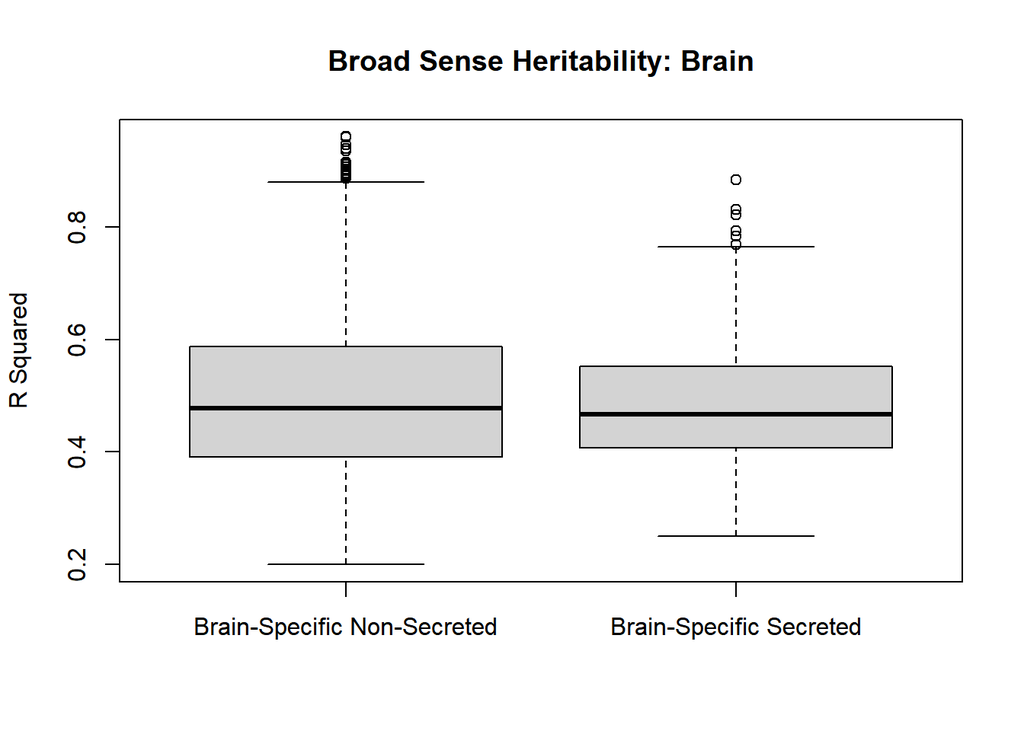

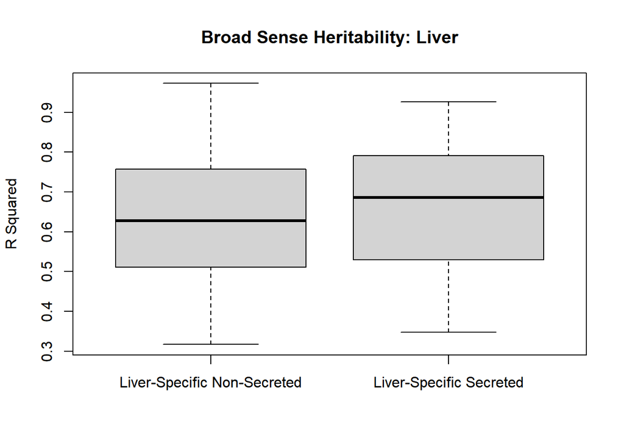